# Overview

Texas Instruments’ mmWave Radar sensor portfolio helps customers build a strong foundation for automated driving. Sensing systems in ADAS (Advanced Driver Assistance Systems) create an accurate perception of the surrounding environment. Newer sensing technologies, such as radar, enhance ADAS by pentrating non-metal objects such as plastic, clothing, and glass while also being generally unaffected by environmental factors such as fog, rain, snow, and flawed or dazzling light. Our automotive (AWRx) device architecture goes beyond the RF/Analog subsystem, integrating processing capabilities onto the chip, offering customers access to a robust portfolio of AWRx devices scaling from high-performance radar front-end to ultra-high resolution, low power, and small single-chip radar.

For more information, take a look at ti.com/awr

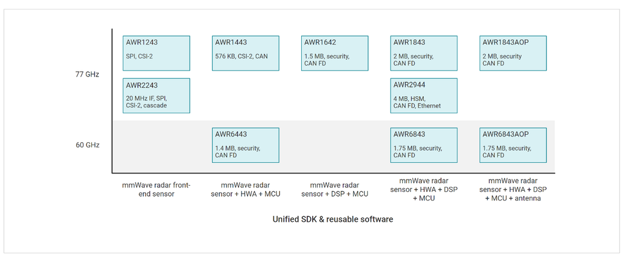

There are multiple benefits to using TI’s mmWave radars:

1. *High resolution* - Less than 5 cm range resolution, range detection to hundreds of meters and velocity of up to 300 Km/h.
2. *Versatile intelligence* - Detect changing operating conditions and adapt to dynamic driving scenarios on the fly.
3. *Small design* - CMOS single-chip sensor integrating best-in-class DSP and MCU in an automotive-friendly package.
4. *Packaging* - To ease the design process of mmWave sensors for our customers, Antenna-on-Package (AoP) technology enables the integration of antenna elements directly into the package substrate, reducing the cost and complexity. Currently, AWR1843AOP is one such device with this package offering.

# Learn more about TI’s mmWave Radar

## White Papers and Technical Articles

1. White Paper – [How Radar is Displacing Traditional Technologies](https://www.ti.com/lit/wp/spry346/spry346.pdf)
2. White Paper – [The fundamentals of millimetre wave Radar sensors](https://www.ti.com/lit/wp/spyy005/spyy005.pdf)
3. White Paper – [Moving from legacy 24 GHz to state-of-the-art 77 GHz radar](https://www.ti.com/lit/wp/spry312/spry312.pdf)
4. White Paper – [TI smart sensors enable automated driving](https://www.ti.com/lit/wp/spyy009/spyy009.pdf)
5. Technical Article – [How AoP technology expands radar sensor placement for automotive applications](https://e2e.ti.com/blogs_/b/behind_the_wheel/posts/how-aop-technology-expands-radar-sensor-placement-for-automotive-applications)

## Demos and Training Videos

1. [Introduction to mmWave radar sensing: FMCW radars](https://training.ti.com/node/1139153)
2. [Getting up and running with TI’s mmwave sensors](https://training.ti.com/getting-and-running-tis-mmwave-sensors)
3. [mmWave Imaging Radar – Automotive Applications](https://training.ti.com/automotive-short-range-radar-demonstration-using-ti-awr-sensors)
4. [Free space sensor demonstration using TI’s mmWave sensor](https://training.ti.com/free-space-sensor-demonstration-using-tis-mmwave-sensor)
5. [Enable smarter automotive sensor integration with TI mmWave AoP technology](https://training.ti.com/webinar-enable-smarter-automotive-sensor-integration-ti-mmwave-aop-technology)

## Functional Safety Resources

1. [Understanding functional safety in automotive and industrial sensing applications](https://e2e.ti.com/blogs_/b/process/posts/understanding-the-importance-of-functional-safety-in-automotive-and-industrial-sensing-applications)
2. [Radar Functional Safety Enablers](https://www.ti.com/lit/fs/sprt747/sprt747.pdf)